# Prosper Loan Data Exploration

## by Nathaniel Essilfie-Conduah

## Introduction

> This project explores and explains the loan data sets from prosper. The data will be assessed explored and explained with visuals. Prosper is a peer to peer lending platform based in San Francisco and offers personal loans for borrowers with good credit (source:https://www.nerdwallet.com/reviews/loans/personal-loans/prosper-personal-loans)

> The focus for this data analysisis is to know what factors influence or affect a loan's outcome application. What also affects a borrower's Annual Percentage rate (APR) or interest rate and differences between loans as a result of the amount.

## Preliminary Wrangling

```python
# import all packages and set plots to be embedded inline
import numpy as np
import pandas as pd
import matplotlib.pyplot as plt
import seaborn as sb

%matplotlib inline
```

```python
# loading the dataset into a pandas dataframe, print statistics
Prosper_df = pd.read_csv('prosperLoanData.csv')
```

```python
# Overview of data
Prosper_df.head()
```

|  | ListingKey | ListingNumber | ListingCreationDate | CreditGrade | Term | LoanStatus | ClosedDate | BorrowerAPR | BorrowerRate | LenderYield | ... | LP_ServiceFees | LP_CollectionFees | LP_GrossPrincipalLoss | LP_NetPrincipalLoss | LP_NonPrincipalRecoverypayments | PercentFunded | Recommendations | InvestmentFromFriendsCount | InvestmentFromFriendsAmount | Investors |
| --- | --- | --- | --- | --- | --- | --- | --- | --- | --- | --- | --- | --- | --- | --- | --- | --- | --- | --- | --- | --- | --- |
| 0 | 1021339766868145413AB3B | 193129 | 2007-08-26 19:09:29.263000000 | C | 36 | Completed | 2009-08-14 00:00:00 | 0.16516 | 0.1580 | 0.1380 | ... | -133.18 | 0.0 | 0.0 | 0.0 | 0.0 | 1.0 | 0 | 0 | 0.0 | 258 |
| 1 | 10273602499503308B223C1 | 1209647 | 2014-02-27 08:28:07.900000000 | NaN | 36 | Current | NaN | 0.12016 | 0.0920 | 0.0820 | ... | 0.00 | 0.0 | 0.0 | 0.0 | 0.0 | 1.0 | 0 | 0 | 0.0 | 1 |
| 2 | 0EE9337825851032864889A | 81716 | 2007-01-05 15:00:47.090000000 | HR | 36 | Completed | 2009-12-17 00:00:00 | 0.28269 | 0.2750 | 0.2400 | ... | -24.20 | 0.0 | 0.0 | 0.0 | 0.0 | 1.0 | 0 | 0 | 0.0 | 41 |
| 3 | 0EF5356002482715299901A | 658116 | 2012-10-22 11:02:35.010000000 | NaN | 36 | Current | NaN | 0.12528 | 0.0974 | 0.0874 | ... | -108.01 | 0.0 | 0.0 | 0.0 | 0.0 | 1.0 | 0 | 0 | 0.0 | 158 |
| 4 | 0F023589499656230C5E3E2 | 909464 | 2013-09-14 18:38:39.097000000 | NaN | 36 | Current | NaN | 0.24614 | 0.2085 | 0.1985 | ... | -60.27 | 0.0 | 0.0 | 0.0 | 0.0 | 1.0 | 0 | 0 | 0.0 | 20 |

5 rows × 81 columns

```python
Prosper_df.shape
```

```
(113937, 81)
```

```python
Prosper_df.dtypes
```

```
ListingKey                      object
ListingNumber                    int64
ListingCreationDate             object
CreditGrade                     object
Term                             int64
                                ...
PercentFunded                  float64
Recommendations                  int64
InvestmentFromFriendsCount       int64
InvestmentFromFriendsAmount    float64
Investors                        int64
Length: 81, dtype: object
```

```python
list(Prosper_df )
```

```
['ListingKey',
 'ListingNumber',
 'ListingCreationDate',
 'CreditGrade',
 'Term',
 'LoanStatus',
 'ClosedDate',
 'BorrowerAPR',
 'BorrowerRate',
 'LenderYield',
 'EstimatedEffectiveYield',
 'EstimatedLoss',
 'EstimatedReturn',
 'ProsperRating (numeric)',
 'ProsperRating (Alpha)',
 'ProsperScore',
 'ListingCategory (numeric)',
 'BorrowerState',
 'Occupation',
 'EmploymentStatus',
 'EmploymentStatusDuration',
 'IsBorrowerHomeowner',
 'CurrentlyInGroup',
 'GroupKey',
 'DateCreditPulled',
 'CreditScoreRangeLower',
 'CreditScoreRangeUpper',
 'FirstRecordedCreditLine',
 'CurrentCreditLines',
 'OpenCreditLines',
 'TotalCreditLinespast7years',
 'OpenRevolvingAccounts',
 'OpenRevolvingMonthlyPayment',
 'InquiriesLast6Months',
 'TotalInquiries',
 'CurrentDelinquencies',
 'AmountDelinquent',
 'DelinquenciesLast7Years',
 'PublicRecordsLast10Years',
 'PublicRecordsLast12Months',
```

[output cut: 26 more lines]

```
 'MemberKey',
 'MonthlyLoanPayment',
 'LP_CustomerPayments',
 'LP_CustomerPrincipalPayments',
 'LP_InterestandFees',
 'LP_ServiceFees',
 'LP_CollectionFees',
 'LP_GrossPrincipalLoss',
 'LP_NetPrincipalLoss',
 'LP_NonPrincipalRecoverypayments',
 'PercentFunded',
 'Recommendations',
 'InvestmentFromFriendsCount',
 'InvestmentFromFriendsAmount',
 'Investors']
```

### What is the structure of your dataset?

> There are 81 coulmns and 113937 entries. The variables in the data set consists of floats, objects, and integers

### What is/are the main feature(s) of interest in your dataset?

> I am interested in finding out the factors that affects one's eligibility to a certain amount of loan

### What features in the dataset do you think will help support your investigation into your feature(s) of interest?

> I expect the Credit score, Borrower APR, employment status, Estimated return and the loan Term to have major effects

**Define**

The listing category here is numeric. From the data dictionary we need to replace it with the category of the listing that the borrower selected when posting their listing:

```
 0 - Not Available
 1 - Debt Consolidation
 2 - Home Improvement
 3 - Business
 4 - Personal Loan
 5 - Student Use
 6 - Auto
 7- Other
 8 - Baby&Adoption
 9 - Boat
 10 - Cosmetic Procedure
 11 - Engagement Ring
 12 - Green Loans
 13 - Household Expenses
 14 - Large Purchases
 15 - Medical/Dental,
 16 -Motorcycle
 17 - RV
 18 - Taxes
 19 - Vacation
 20 - Wedding Loans
```

**Code**

```python
Prosper_df['ListingCategory (numeric)'] = Prosper_df['ListingCategory (numeric)'].replace({
    0: 'Not Available',
    1: 'Debt Consolidation',
    2: 'Home Improvement',
    3: 'Business',
    4: 'Personal Loan',
    5: 'Student Use',
    6: 'Auto',
    7: 'Other',
    8: 'Baby&Adoption',
    9: 'Boat',
    10: 'Cosmetic Procedure',
    11: 'Engagement Ring',
    12: 'Green Loans',
    13: 'Household Expenses',
    14: 'Large Purchases',
    15: 'Medical/Dental',
    16: 'Motorcycle',
    17: 'RV',
    18: 'Taxes',
    19: 'Vacation',
    20: 'Wedding Loans'})
```

**Test**

```python
Prosper_df['ListingCategory (numeric)'].value_counts()
```

```
Debt Consolidation    58308
Not Available         16965
Other                 10494
Home Improvement       7433
Business               7189
Auto                   2572
Personal Loan          2395
Household Expenses     1996
Medical/Dental         1522
Taxes                   885
Large Purchases         876
Wedding Loans           771
Vacation                768
Student Use             756
Motorcycle              304
Engagement Ring         217
Baby&Adoption           199
Cosmetic Procedure       91
Boat                     85
Green Loans              59
RV                       52
Name: ListingCategory (numeric), dtype: int64
```

**Define**

Renaming the ListingCategory (numeric) to ListingCategory

**Code**

```python
Prosper_df.rename(columns = {'ListingCategory (numeric)':'ListingCategory'}, inplace=True)
```

**Test**

```python
Prosper_df['ListingCategory']
```

```
0              Not Available
1           Home Improvement
2              Not Available
3                 Motorcycle
4           Home Improvement
                 ...
113932    Debt Consolidation
113933                 Other
113934    Debt Consolidation
113935      Home Improvement
113936    Debt Consolidation
Name: ListingCategory, Length: 113937, dtype: object
```

**Define**

We can tell the names of all the columns within the data set by using the list function. Some selected columns will be used for the data analysis

**Code**

```python
# Selecting columns to be used for the data analysis
Prosper_clean = Prosper_df.copy()
Prosper_clean = Prosper_clean[['ListingKey',  'ListingCreationDate', 'Term', 'LoanStatus', 'BorrowerAPR', 'LenderYield', 'EstimatedReturn', 'ListingCategory', 'BorrowerState', 'EmploymentStatus', 'IsBorrowerHomeowner', 'CreditScoreRangeLower', 'IncomeRange', 'MonthlyLoanPayment', 'LoanMonthsSinceOrigination', 'LoanOriginalAmount', 'Recommendations']]
```

```python
# Checking to see the new list of columns for our data
Prosper_clean.info()
```

```
<class 'pandas.core.frame.DataFrame'>
RangeIndex: 113937 entries, 0 to 113936
Data columns (total 17 columns):
 #   Column                      Non-Null Count   Dtype
---  ------                      --------------   -----
 0   ListingKey                  113937 non-null  object
 1   ListingCreationDate         113937 non-null  object
 2   Term                        113937 non-null  int64
 3   LoanStatus                  113937 non-null  object
 4   BorrowerAPR                 113912 non-null  float64
 5   LenderYield                 113937 non-null  float64
 6   EstimatedReturn             84853 non-null   float64
 7   ListingCategory             113937 non-null  object
 8   BorrowerState               108422 non-null  object
 9   EmploymentStatus            111682 non-null  object
 10  IsBorrowerHomeowner         113937 non-null  bool
 11  CreditScoreRangeLower       113346 non-null  float64
 12  IncomeRange                 113937 non-null  object
 13  MonthlyLoanPayment          113937 non-null  float64
 14  LoanMonthsSinceOrigination  113937 non-null  int64
 15  LoanOriginalAmount          113937 non-null  int64
 16  Recommendations             113937 non-null  int64
dtypes: bool(1), float64(5), int64(4), object(7)
memory usage: 14.0+ MB
```

**Test**

```python
Prosper_clean.shape
```

```
(113937, 17)
```

The new data frame which is the Prosper_clean has 113937 rows and 17 columns. I chose 17 columns out of the 81 because I believe these variables are very crucial and influential with respect to one's laon application outcome

```python
Prosper_clean
```

|  | ListingKey | ListingCreationDate | Term | LoanStatus | BorrowerAPR | LenderYield | EstimatedReturn | ListingCategory | BorrowerState | EmploymentStatus | IsBorrowerHomeowner | CreditScoreRangeLower | IncomeRange | MonthlyLoanPayment | LoanMonthsSinceOrigination | LoanOriginalAmount | Recommendations |
| --- | --- | --- | --- | --- | --- | --- | --- | --- | --- | --- | --- | --- | --- | --- | --- | --- | --- |
| 0 | 1021339766868145413AB3B | 2007-08-26 19:09:29.263000000 | 36 | Completed | 0.16516 | 0.1380 | NaN | Not Available | CO | Self-employed | True | 640.0 | $25,000-49,999 | 330.43 | 78 | 9425 | 0 |
| 1 | 10273602499503308B223C1 | 2014-02-27 08:28:07.900000000 | 36 | Current | 0.12016 | 0.0820 | 0.05470 | Home Improvement | CO | Employed | False | 680.0 | $50,000-74,999 | 318.93 | 0 | 10000 | 0 |
| 2 | 0EE9337825851032864889A | 2007-01-05 15:00:47.090000000 | 36 | Completed | 0.28269 | 0.2400 | NaN | Not Available | GA | Not available | False | 480.0 | Not displayed | 123.32 | 86 | 3001 | 0 |
| 3 | 0EF5356002482715299901A | 2012-10-22 11:02:35.010000000 | 36 | Current | 0.12528 | 0.0874 | 0.06000 | Motorcycle | GA | Employed | True | 800.0 | $25,000-49,999 | 321.45 | 16 | 10000 | 0 |
| 4 | 0F023589499656230C5E3E2 | 2013-09-14 18:38:39.097000000 | 36 | Current | 0.24614 | 0.1985 | 0.09066 | Home Improvement | MN | Employed | True | 680.0 | $100,000+ | 563.97 | 6 | 15000 | 0 |
| ... | ... | ... | ... | ... | ... | ... | ... | ... | ... | ... | ... | ... | ... | ... | ... | ... | ... |
| 113932 | E6D9357655724827169606C | 2013-04-14 05:55:02.663000000 | 36 | Current | 0.22354 | 0.1764 | 0.09500 | Debt Consolidation | IL | Employed | True | 700.0 | $50,000-74,999 | 364.74 | 11 | 10000 | 0 |
| 113933 | E6DB353036033497292EE43 | 2011-11-03 20:42:55.333000000 | 36 | FinalPaymentInProgress | 0.13220 | 0.1010 | 0.08070 | Other | PA | Employed | True | 700.0 | $75,000-99,999 | 65.57 | 28 | 2000 | 0 |
| 113934 | E6E13596170052029692BB1 | 2013-12-13 05:49:12.703000000 | 60 | Current | 0.23984 | 0.2050 | 0.08578 | Debt Consolidation | TX | Employed | True | 700.0 | $25,000-49,999 | 273.35 | 3 | 10000 | 0 |
| 113935 | E6EB3531504622671970D9E | 2011-11-14 13:18:26.597000000 | 60 | Completed | 0.28408 | 0.2505 | 0.15950 | Home Improvement | GA | Full-time | True | 680.0 | $25,000-49,999 | 449.55 | 28 | 15000 | 0 |
| 113936 | E6ED3600409833199F711B7 | 2014-01-15 09:27:37.657000000 | 36 | Current | 0.13189 | 0.0939 | 0.06081 | Debt Consolidation | NY | Employed | False | 680.0 | $50,000-74,999 | 64.90 | 2 | 2000 | 0 |

113937 rows × 17 columns

```python
Prosper_clean.sample(50)
```

|  | ListingKey | ListingCreationDate | Term | LoanStatus | BorrowerAPR | LenderYield | EstimatedReturn | ListingCategory | BorrowerState | EmploymentStatus | IsBorrowerHomeowner | CreditScoreRangeLower | IncomeRange | MonthlyLoanPayment | LoanMonthsSinceOrigination | LoanOriginalAmount | Recommendations |
| --- | --- | --- | --- | --- | --- | --- | --- | --- | --- | --- | --- | --- | --- | --- | --- | --- | --- |
| 49076 | B2CE359699018428779CC79 | 2013-12-16 15:09:54.180000000 | 36 | Current | 0.21342 | 0.1665 | 0.08022 | Debt Consolidation | VA | Employed | True | 680.0 | $100,000+ | 305.81 | 3 | 8500 | 0 |
| 40631 | 89A73389872962340343412 | 2007-05-16 10:04:00.417000000 | 36 | Completed | 0.16697 | 0.1498 | NaN | Not Available | MI | Full-time | True | 640.0 | $50,000-74,999 | 316.32 | 82 | 9000 | 0 |
| 68396 | 360E35991455766782A3278 | 2013-12-30 06:11:18.157000000 | 60 | Current | 0.23267 | 0.1980 | 0.08474 | Debt Consolidation | MI | Employed | False | 660.0 | $25,000-49,999 | 242.47 | 2 | 9000 | 0 |
| 20618 | A0DB359586065129248F394 | 2013-11-26 07:34:01.270000000 | 36 | Current | 0.11563 | 0.0779 | 0.05342 | Debt Consolidation | RI | Employed | True | 740.0 | $50,000-74,999 | 475.53 | 3 | 15000 | 0 |
| 63113 | 0E973419172256137F5843C | 2008-04-21 12:38:15.087000000 | 36 | Completed | 0.21679 | 0.1845 | NaN | Debt Consolidation | WA | Full-time | True | 660.0 | $25,000-49,999 | 36.88 | 71 | 1000 | 0 |
| 41303 | DDFA3551319611630F660F7 | 2012-07-05 07:45:04.693000000 | 36 | Completed | 0.12427 | 0.0864 | 0.06620 | Other | GA | Full-time | True | 800.0 | $50,000-74,999 | 320.98 | 20 | 10000 | 0 |
| 38058 | 8B073594787175427D1B5D3 | 2013-11-08 00:52:07.857000000 | 36 | Completed | 0.22108 | 0.1740 | 0.08724 | Debt Consolidation | VA | Employed | True | 660.0 | $75,000-99,999 | 327.18 | 3 | 9000 | 0 |
| 107116 | 64DF3502071131683DAA28F | 2010-12-09 20:45:39.833000000 | 36 | Chargedoff | 0.35858 | 0.3120 | 0.15570 | Other | CT | Employed | True | 640.0 | $75,000-99,999 | 327.49 | 39 | 7500 | 0 |
| 15069 | 07E93549515845549B0901B | 2012-06-12 13:31:02.103000000 | 36 | Current | 0.25259 | 0.2048 | 0.11100 | Engagement Ring | FL | Employed | False | 740.0 | $25,000-49,999 | 246.49 | 21 | 6500 | 0 |
| 44310 | 4D80356160226819813119A | 2012-10-16 19:27:01.433000000 | 36 | Current | 0.35797 | 0.3077 | 0.11740 | Vacation | WA | Employed | True | 720.0 | $50,000-74,999 | 151.99 | 17 | 3500 | 0 |
| 61153 | C38D3391846253249F0B194 | 2007-06-09 17:58:38.297000000 | 36 | Chargedoff | 0.11696 | 0.1050 | NaN | Not Available | TX | Full-time | True | 740.0 | $25,000-49,999 | 327.39 | 81 | 10000 | 1 |
| 73137 | 0B893587807498875F4F261 | 2013-08-30 14:05:05.930000000 | 60 | Current | 0.24589 | 0.2109 | 0.11330 | Debt Consolidation | CA | Employed | False | 700.0 | $25,000-49,999 | 110.68 | 6 | 4000 | 0 |
| 97502 | AF34349231479421495B7C4 | 2010-08-17 23:43:20.693000000 | 36 | Completed | 0.08591 | 0.0725 | 0.05700 | Debt Consolidation | WI | Employed | True | 800.0 | $50,000-74,999 | 251.61 | 43 | 8000 | 0 |
| 64 | 0F1B35892502944590155D8 | 2013-09-26 11:16:17.373000000 | 36 | Current | 0.30899 | 0.2599 | 0.10423 | Debt Consolidation | NJ | Employed | True | 680.0 | $25,000-49,999 | 204.10 | 5 | 5000 | 0 |
| 57569 | 5190360226194186933061C | 2014-02-04 12:46:43.637000000 | 36 | Current | 0.12081 | 0.0830 | 0.05568 | Debt Consolidation | MA | Self-employed | False | 780.0 | $100,000+ | 479.09 | 1 | 15000 | 0 |
| 20979 | F748355002262941991D1B4 | 2012-06-22 13:31:02.793000000 | 60 | Completed | 0.17849 | 0.1451 | 0.11150 | Large Purchases | SC | Employed | False | 780.0 | $75,000-99,999 | 168.41 | 21 | 7000 | 0 |
| 101851 | 6DD33555558966501A830DE | 2012-08-23 08:40:00.833000000 | 60 | Current | 0.15936 | 0.1264 | 0.10100 | Business | SC | Not employed | False | 780.0 | Not employed | 346.23 | 19 | 15000 | 0 |
| 84730 | 3D5D3530843097281AC7D1B | 2011-11-01 09:22:01.730000000 | 36 | Current | 0.35244 | 0.3060 | 0.14300 | Business | CO | Self-employed | True | 640.0 | $50,000-74,999 | 324.99 | 28 | 7500 | 0 |
| 14166 | 0F983420346910834EE10F7 | 2008-05-08 11:16:38.660000000 | 36 | Completed | 0.16461 | 0.1330 | NaN | Debt Consolidation | CA | Full-time | False | 620.0 | $1-24,999 | 100.14 | 70 | 4000 | 1 |
| 10843 | 13A435515238528345F5783 | 2012-07-04 05:08:26.420000000 | 36 | Completed | 0.26395 | 0.2159 | 0.11320 | Business | CA | Employed | False | 640.0 | $50,000-74,999 | 192.48 | 19 | 5000 | 1 |
| 2351 | 2BB73515078872837E2F2D6 | 2011-05-08 16:03:02.437000000 | 60 | Defaulted | 0.27322 | 0.2399 | 0.13400 | Debt Consolidation | MN | Employed | False | 620.0 | $50,000-74,999 | 293.45 | 34 | 10000 | 0 |
| 112637 | CB7D3484329678355B6E913 | 2010-05-20 15:15:38.670000000 | 36 | Completed | 0.08591 | 0.0725 | 0.05700 | Other | CA | Full-time | False | 740.0 | $100,000+ | 314.52 | 43 | 10000 | 0 |
| 113693 | E2193428655642974D34A0B | 2008-07-31 21:40:08.397000000 | 36 | Defaulted | 0.27103 | 0.2380 | NaN | Debt Consolidation | PA | Full-time | False | 640.0 | $25,000-49,999 | 115.00 | 67 | 2900 | 0 |
| 88920 | AE6035656431517591370FF | 2012-12-05 12:45:38.717000000 | 36 | Chargedoff | 0.35797 | 0.3077 | 0.11240 | Debt Consolidation | MO | Employed | True | 680.0 | $50,000-74,999 | 157.64 | 15 | 3630 | 0 |
| 69536 | 40023493625216988507E8E | 2010-08-24 15:52:59.587000000 | 36 | Completed | 0.37699 | 0.3300 | 0.12750 | Debt Consolidation | CA | Employed | False | 660.0 | $1-24,999 | 178.69 | 42 | 4000 | 1 |
| 84469 | 21C93396540024942BAC5BA | 2007-08-13 06:15:17.180000000 | 36 | Chargedoff | 0.21480 | 0.1800 | NaN | Not Available | MI | Full-time | False | 520.0 | $75,000-99,999 | 50.54 | 79 | 1360 | 0 |
| 38433 | 735E35343319087267136F6 | 2011-12-27 06:37:50.830000000 | 60 | Completed | 0.32989 | 0.2927 | 0.17330 | Other | NJ | Employed | True | 780.0 | $1-24,999 | 227.64 | 27 | 7000 | 0 |
| 41357 | 789B358308304267155EB14 | 2013-07-16 14:26:15.890000000 | 60 | Current | 0.17522 | 0.1419 | 0.08760 | Debt Consolidation | UT | Employed | True | 700.0 | $100,000+ | 477.80 | 8 | 20000 | 0 |
| 59344 | FF823575742981280A45E99 | 2013-04-20 06:15:27.967000000 | 36 | Current | 0.14857 | 0.1103 | 0.07120 | Household Expenses | OH | Employed | False | 720.0 | $50,000-74,999 | 172.79 | 10 | 5200 | 0 |
| 14492 | 0F75342572091879597E09A | 2008-07-17 12:00:08.270000000 | 36 | Chargedoff | 0.37453 | 0.3400 | NaN | Debt Consolidation | AZ | Full-time | False | 520.0 | $1-24,999 | 67.85 | 68 | 1500 | 0 |
| 8548 | 3F6336027715644199F2CA2 | 2014-02-12 20:03:06.487000000 | 36 | Current | 0.22505 | 0.1775 | 0.08223 | Debt Consolidation | LA | Employed | False | 680.0 | $25,000-49,999 | 365.30 | 0 | 10000 | 0 |
| 34553 | 9276360067832614349CEB6 | 2014-02-01 15:28:14.737000000 | 60 | Current | 0.21166 | 0.1775 | 0.08223 | Debt Consolidation | VA | Employed | True | 720.0 | $25,000-49,999 | 258.03 | 1 | 10000 | 0 |
| 11602 | 66FD3508735355060137253 | 2011-02-22 12:07:02.773000000 | 36 | Completed | 0.35643 | 0.3099 | 0.14870 | Debt Consolidation | CA | Employed | False | 660.0 | $25,000-49,999 | 326.62 | 35 | 7500 | 0 |
| 47591 | 8E2635844209231500969EE | 2013-07-21 17:55:45.217000000 | 36 | Past Due (31-60 days) | 0.23121 | 0.1839 | 0.09650 | Home Improvement | PA | Employed | True | 720.0 | $25,000-49,999 | 73.71 | 8 | 2000 | 0 |
| 74929 | B35F33650920601385A7AA2 | 2006-05-04 08:32:53.953000000 | 36 | Completed | 0.24502 | 0.2325 | NaN | Not Available | NaN | NaN | False | 620.0 | Not displayed | 156.41 | 94 | 4000 | 0 |
| 75162 | 41C13597651905858BB97A8 | 2013-12-10 09:03:49.707000000 | 36 | Current | 0.18275 | 0.1365 | 0.07408 | Debt Consolidation | MS | Employed | False | 680.0 | $25,000-49,999 | 275.95 | 2 | 8000 | 0 |
| 43809 | 969F3415964018461D08A37 | 2008-03-11 07:30:41.930000000 | 36 | Defaulted | 0.23504 | 0.2025 | NaN | Personal Loan | GA | Self-employed | True | 660.0 | $100,000+ | 359.13 | 72 | 9500 | 0 |
| 77344 | F6103401029183293AF753C | 2007-10-02 20:40:11.747000000 | 36 | Completed | 0.15932 | 0.1350 | NaN | Not Available | GA | Full-time | False | 580.0 | $25,000-49,999 | 146.29 | 77 | 4250 | 0 |
| 34655 | ADF935831311942917D0FAE | 2013-06-24 11:18:29.130000000 | 60 | Current | 0.13942 | 0.1069 | 0.07060 | Debt Consolidation | NJ | Employed | True | 760.0 | $100,000+ | 331.32 | 9 | 15000 | 0 |
| 24936 | BA20360083955710791A00A | 2014-01-16 14:49:37.600000000 | 36 | Current | 0.20217 | 0.1555 | 0.07819 | Debt Consolidation | IL | Self-employed | True | 660.0 | $100,000+ | 531.44 | 2 | 15000 | 0 |
| 65484 | CAF53501939151112454B99 | 2010-12-21 05:51:26.503000000 | 36 | Completed | 0.22872 | 0.1849 | 0.09360 | Debt Consolidation | GA | Employed | True | 640.0 | $25,000-49,999 | 103.33 | 36 | 2800 | 0 |
| 57939 | 5F423408728042901212E40 | 2007-12-26 17:38:31.127000000 | 36 | Chargedoff | 0.18816 | 0.1709 | NaN | Personal Loan | CA | Full-time | False | 700.0 | $1-24,999 | 235.28 | 74 | 6500 | 0 |
| 84390 | 21AB3584259963178677003 | 2013-07-22 14:22:34.673000000 | 60 | Current | 0.21566 | 0.1814 | 0.10530 | Debt Consolidation | MO | Employed | True | 680.0 | $50,000-74,999 | 390.26 | 8 | 15000 | 0 |
| 102421 | AB86354886146383363D794 | 2012-06-08 13:24:14.097000000 | 36 | Current | 0.26681 | 0.2187 | 0.11440 | Debt Consolidation | CA | Employed | True | 640.0 | $100,000+ | 270.49 | 21 | 7000 | 0 |
| 38578 | 76ED35521199666669EBBD0 | 2012-07-02 08:46:50 | 60 | Current | 0.17849 | 0.1451 | 0.11150 | Debt Consolidation | NJ | Employed | False | 800.0 | $50,000-74,999 | 481.17 | 20 | 20000 | 0 |
| 35205 | B57B3546436796203A888E4 | 2012-05-15 09:21:27.857000000 | 60 | Current | 0.31375 | 0.2770 | 0.15110 | Home Improvement | CA | Employed | True | 760.0 | $100,000+ | 473.39 | 22 | 15000 | 0 |
| 72364 | F9333496305196102326772 | 2010-10-04 22:49:19.860000000 | 36 | Completed | 0.38058 | 0.3335 | 0.17610 | Other | MN | Other | False | 680.0 | $1-24,999 | 224.34 | 41 | 5000 | 0 |
| 19072 | 1D55360048100111156E7C4 | 2014-01-31 16:57:55.937000000 | 36 | Current | 0.30848 | 0.2594 | 0.09858 | Debt Consolidation | NY | Employed | False | 680.0 | $1-24,999 | 163.17 | 1 | 4000 | 0 |
| 78286 | D86A3407108240307D9BDD2 | 2007-11-25 12:03:34.943000000 | 36 | Defaulted | 0.10991 | 0.0860 | NaN | Not Available | HI | Full-time | False | 560.0 | $1-24,999 | 192.48 | 76 | 6000 | 0 |
| 9774 | 16CC354525216306170EF29 | 2012-05-02 18:23:30.977000000 | 36 | Current | 0.21372 | 0.1668 | 0.10740 | Debt Consolidation | DC | Employed | True | 740.0 | $75,000-99,999 | 431.90 | 22 | 12000 | 0 |

```python
# Assessing the Recommendation column to identify the values within it.

Prosper_clean.Recommendations
```

```
0         0
1         0
2         0
3         0
4         0
         ..
113932    0
113933    0
113934    0
113935    0
113936    0
Name: Recommendations, Length: 113937, dtype: int64
```

```python
Prosper_clean.Recommendations.value_counts()
```

```
0     109678
1       3516
2        568
3        108
4         26
5         14
9          6
7          5
6          4
8          3
18         2
16         2
14         1
21         1
24         1
19         1
39         1
Name: Recommendations, dtype: int64
```

```python
#Checking to see if there are any null values within the dataset

Prosper_clean.isnull()
```

|  | ListingKey | ListingCreationDate | Term | LoanStatus | BorrowerAPR | LenderYield | EstimatedReturn | ListingCategory | BorrowerState | EmploymentStatus | IsBorrowerHomeowner | CreditScoreRangeLower | IncomeRange | MonthlyLoanPayment | LoanMonthsSinceOrigination | LoanOriginalAmount | Recommendations |
| --- | --- | --- | --- | --- | --- | --- | --- | --- | --- | --- | --- | --- | --- | --- | --- | --- | --- |
| 0 | False | False | False | False | False | False | True | False | False | False | False | False | False | False | False | False | False |
| 1 | False | False | False | False | False | False | False | False | False | False | False | False | False | False | False | False | False |
| 2 | False | False | False | False | False | False | True | False | False | False | False | False | False | False | False | False | False |
| 3 | False | False | False | False | False | False | False | False | False | False | False | False | False | False | False | False | False |
| 4 | False | False | False | False | False | False | False | False | False | False | False | False | False | False | False | False | False |
| ... | ... | ... | ... | ... | ... | ... | ... | ... | ... | ... | ... | ... | ... | ... | ... | ... | ... |
| 113932 | False | False | False | False | False | False | False | False | False | False | False | False | False | False | False | False | False |
| 113933 | False | False | False | False | False | False | False | False | False | False | False | False | False | False | False | False | False |
| 113934 | False | False | False | False | False | False | False | False | False | False | False | False | False | False | False | False | False |
| 113935 | False | False | False | False | False | False | False | False | False | False | False | False | False | False | False | False | False |
| 113936 | False | False | False | False | False | False | False | False | False | False | False | False | False | False | False | False | False |

113937 rows × 17 columns

```python
Prosper_clean.isnull().sum()
```

```
ListingKey                        0
ListingCreationDate               0
Term                              0
LoanStatus                        0
BorrowerAPR                      25
LenderYield                       0
EstimatedReturn               29084
ListingCategory                   0
BorrowerState                  5515
EmploymentStatus               2255
IsBorrowerHomeowner               0
CreditScoreRangeLower           591
IncomeRange                       0
MonthlyLoanPayment                0
LoanMonthsSinceOrigination        0
LoanOriginalAmount                0
Recommendations                   0
dtype: int64
```

**Define**

The table depicts EstimatedReturn, BorrowerState, EmploymentStatus, CreditScoreRangeLower having null values in the dataset.

**Code**

```python
# drop null values in BorrowerState, EmploymentStatus, CreditScoreRangeLower and leave the EstimatedReturn,since from the data dictionary it originated from july 2009

Prosper_clean= Prosper_clean.dropna(subset = ['BorrowerState', 'CreditScoreRangeLower', 'EmploymentStatus'], how = 'any' )
Prosper_clean.isnull().sum()
```

```
ListingKey                        0
ListingCreationDate               0
Term                              0
LoanStatus                        0
BorrowerAPR                       0
LenderYield                       0
EstimatedReturn               22701
ListingCategory                   0
BorrowerState                     0
EmploymentStatus                  0
IsBorrowerHomeowner               0
CreditScoreRangeLower             0
IncomeRange                       0
MonthlyLoanPayment                0
LoanMonthsSinceOrigination        0
LoanOriginalAmount                0
Recommendations                   0
dtype: int64
```

**Test**

```python
Prosper_clean.EstimatedReturn
```

```
0             NaN
1         0.05470
2             NaN
3         0.06000
4         0.09066
           ...
113932    0.09500
113933    0.08070
113934    0.08578
113935    0.15950
113936    0.06081
Name: EstimatedReturn, Length: 107554, dtype: float64
```

```python
Prosper_clean.sample(50)
```

|  | ListingKey | ListingCreationDate | Term | LoanStatus | BorrowerAPR | LenderYield | EstimatedReturn | ListingCategory | BorrowerState | EmploymentStatus | IsBorrowerHomeowner | CreditScoreRangeLower | IncomeRange | MonthlyLoanPayment | LoanMonthsSinceOrigination | LoanOriginalAmount | Recommendations |
| --- | --- | --- | --- | --- | --- | --- | --- | --- | --- | --- | --- | --- | --- | --- | --- | --- | --- |
| 103842 | 6F6D3574428755227FFAA0E | 2013-03-20 07:31:30.750000000 | 36 | Completed | 0.22354 | 0.1764 | 0.09500 | Taxes | AZ | Employed | True | 700.0 | $50,000-74,999 | 164.13 | 12 | 4500 | 0 |
| 74477 | 873D3579067992952ED51D7 | 2013-05-14 00:26:56.320000000 | 36 | Current | 0.23530 | 0.1879 | 0.09750 | Medical/Dental | AZ | Employed | True | 640.0 | $50,000-74,999 | 118.95 | 10 | 3210 | 0 |
| 65693 | 71EB34297447580213C9A16 | 2008-09-03 15:14:58.557000000 | 36 | Completed | 0.37453 | 0.3400 | NaN | Debt Consolidation | NH | Full-time | False | 620.0 | $1-24,999 | 72.38 | 66 | 1600 | 0 |
| 102094 | 40D83595302073547B7E132 | 2013-11-29 07:39:58.707000000 | 36 | Current | 0.07922 | 0.0559 | 0.04261 | Debt Consolidation | NY | Employed | False | 780.0 | $75,000-99,999 | 563.47 | 3 | 18360 | 0 |
| 22726 | EBE835209935108762ED006 | 2011-07-26 15:40:21.853000000 | 36 | Completed | 0.22362 | 0.1799 | 0.11470 | Debt Consolidation | IL | Full-time | False | 720.0 | $25,000-49,999 | 73.30 | 32 | 2000 | 0 |
| 32969 | 0071352742552723510F6E5 | 2011-10-06 14:14:50.817000000 | 12 | Completed | 0.34105 | 0.2399 | 0.12200 | Home Improvement | FL | Employed | True | 780.0 | $50,000-74,999 | 656.24 | 29 | 7000 | 0 |
| 64700 | 0CFD36035364614796192E7 | 2014-02-20 18:02:18.483000000 | 60 | Current | 0.16686 | 0.1335 | 0.07400 | Debt Consolidation | NY | Employed | False | 700.0 | $25,000-49,999 | 152.43 | 1 | 6500 | 0 |
| 86486 | 435335706586501865E6DE1 | 2013-02-08 08:31:22.550000000 | 36 | Current | 0.08325 | 0.0599 | 0.04660 | Home Improvement | VA | Employed | True | 800.0 | $100,000+ | 228.46 | 13 | 7400 | 0 |
| 68751 | FFAC354811044392378CE9F | 2012-06-06 10:42:24.437000000 | 36 | Chargedoff | 0.35797 | 0.3077 | 0.12460 | Debt Consolidation | PA | Employed | True | 700.0 | $25,000-49,999 | 130.28 | 21 | 3000 | 0 |
| 59375 | 758535804214975482EE8ED | 2013-06-06 12:55:43.050000000 | 60 | Current | 0.33040 | 0.2932 | 0.12420 | Debt Consolidation | MS | Employed | True | 680.0 | $25,000-49,999 | 130.20 | 9 | 4000 | 0 |
| 108875 | 265D3400873933759E194FC | 2007-09-26 05:09:42.640000000 | 36 | Completed | 0.21739 | 0.2000 | NaN | Not Available | NC | Full-time | False | 620.0 | $50,000-74,999 | 339.08 | 77 | 9000 | 0 |
| 2779 | 0D7F35491337371222F9914 | 2012-06-13 12:39:02.337000000 | 36 | Completed | 0.12427 | 0.0864 | 0.06620 | Debt Consolidation | IN | Employed | True | 700.0 | $25,000-49,999 | 641.97 | 21 | 20000 | 0 |
| 21656 | 64703571975073324F61D1B | 2013-03-05 10:36:30.060000000 | 36 | Current | 0.21025 | 0.1634 | 0.09120 | Debt Consolidation | TX | Employed | True | 700.0 | $50,000-74,999 | 537.33 | 12 | 15000 | 0 |
| 68444 | 39153580061577347A97B6E | 2013-05-30 08:16:35.607000000 | 36 | Current | 0.31790 | 0.2686 | 0.11220 | Medical/Dental | NJ | Employed | True | 680.0 | $75,000-99,999 | 165.15 | 9 | 4000 | 0 |
| 28894 | 2F993590951510863B8498A | 2013-10-01 08:33:08.517000000 | 36 | Current | 0.26917 | 0.2210 | 0.09512 | Debt Consolidation | TN | Employed | False | 660.0 | $1-24,999 | 155.05 | 5 | 4000 | 0 |
| 71649 | 88D3352879939554124CC7E | 2011-10-21 18:51:57.210000000 | 36 | Completed | 0.35132 | 0.3049 | 0.14390 | Other | VA | Other | True | 720.0 | $100,000+ | 302.90 | 29 | 7000 | 0 |
| 52729 | DB69338674499453078768F | 2007-04-05 07:21:09.943000000 | 36 | Completed | 0.15713 | 0.1350 | NaN | Not Available | NY | Full-time | False | 660.0 | $25,000-49,999 | 346.62 | 83 | 9999 | 1 |
| 5146 | 9CE4354451015381412AF81 | 2012-04-12 18:14:13.200000000 | 36 | Completed | 0.26681 | 0.2187 | 0.11440 | Business | MO | Employed | True | 680.0 | $0 | 444.38 | 23 | 11500 | 0 |
| 87226 | E76835856890458987472E7 | 2013-08-07 18:37:01.863000000 | 36 | Current | 0.31790 | 0.2686 | 0.11220 | Business | VA | Full-time | True | 680.0 | $100,000+ | 165.15 | 7 | 4000 | 0 |
| 83011 | 710D3597043824784958829 | 2013-12-11 09:50:51.573000000 | 60 | Current | 0.16662 | 0.1335 | 0.07400 | Debt Consolidation | NV | Other | False | 720.0 | $50,000-74,999 | 351.75 | 2 | 15000 | 0 |
| 103483 | E05C340450194922211414E | 2007-11-15 10:06:24.147000000 | 36 | Completed | 0.16717 | 0.1500 | NaN | Not Available | CA | Full-time | False | 620.0 | $50,000-74,999 | 87.89 | 76 | 2500 | 1 |
| 47855 | 33793425663589312650BE4 | 2008-06-29 21:43:53.943000000 | 36 | Completed | 0.37453 | 0.3400 | NaN | Debt Consolidation | AL | Full-time | False | 560.0 | $50,000-74,999 | 0.00 | 68 | 3000 | 0 |
| 104094 | 0F933389844535057B95969 | 2007-05-17 16:17:01.303000000 | 36 | Chargedoff | 0.30564 | 0.2800 | NaN | Not Available | CA | Full-time | False | 540.0 | $75,000-99,999 | 125.72 | 82 | 3000 | 0 |
| 29658 | 921035885758242923750B3 | 2013-09-18 08:43:53.493000000 | 36 | Current | 0.30899 | 0.2599 | 0.10423 | Debt Consolidation | GA | Employed | False | 640.0 | $50,000-74,999 | 163.28 | 6 | 4000 | 0 |
| 83769 | CBB7355498735637628690A | 2012-08-15 23:53:45.690000000 | 60 | Past Due (1-15 days) | 0.18545 | 0.1519 | 0.11640 | Debt Consolidation | WA | Full-time | False | 660.0 | $75,000-99,999 | 427.33 | 19 | 17500 | 0 |
| 94652 | F71F36034333911576B4B37 | 2014-03-05 04:43:01.950000000 | 36 | Current | 0.16259 | 0.1164 | 0.06598 | Debt Consolidation | MO | Employed | False | 700.0 | $100,000+ | 838.02 | 0 | 25000 | 0 |
| 80202 | F8BD3603093000950CED557 | 2014-02-25 12:24:24.993000000 | 36 | Current | 0.23375 | 0.1860 | 0.07907 | Debt Consolidation | TX | Employed | False | 720.0 | $50,000-74,999 | 369.60 | 0 | 10000 | 0 |
| 24412 | 77CB355440305520937F907 | 2012-08-05 17:57:32.697000000 | 36 | Current | 0.28339 | 0.2349 | 0.11660 | Other | NJ | Other | False | 680.0 | $25,000-49,999 | 78.98 | 19 | 2000 | 0 |
| 54641 | FF013560637147541A27F10 | 2012-10-22 19:21:43.067000000 | 60 | Chargedoff | 0.28848 | 0.2524 | 0.12950 | Debt Consolidation | GA | Full-time | False | 660.0 | $25,000-49,999 | 135.37 | 16 | 4500 | 0 |
| 45840 | A4223583683051691A1D853 | 2013-06-30 13:17:53.767000000 | 36 | Current | 0.21945 | 0.1724 | 0.09410 | Debt Consolidation | OK | Employed | False | 660.0 | $75,000-99,999 | 544.09 | 8 | 15000 | 0 |
| 27649 | 638F357264549710416F390 | 2013-03-15 12:34:28.583000000 | 36 | Current | 0.13138 | 0.0934 | 0.06310 | Other | MI | Employed | True | 740.0 | $50,000-74,999 | 64.85 | 12 | 2000 | 0 |
| 34200 | 91DA3396741561245FF65F5 | 2007-08-12 13:49:28.760000000 | 36 | Chargedoff | 0.18927 | 0.1720 | NaN | Not Available | MA | Full-time | True | 640.0 | $25,000-49,999 | 253.77 | 79 | 7000 | 0 |
| 81749 | 431A34783231873755B7713 | 2010-03-12 10:03:07.870000000 | 36 | Completed | 0.11296 | 0.0820 | 0.06080 | Debt Consolidation | NC | Full-time | False | 700.0 | $25,000-49,999 | 125.78 | 48 | 4000 | 0 |
| 23260 | 7688340911319519038E1B0 | 2007-12-23 05:04:22.820000000 | 36 | Completed | 0.07799 | 0.0609 | NaN | Personal Loan | CT | Full-time | True | 780.0 | $100,000+ | 30.46 | 74 | 1000 | 0 |
| 71243 | C7343390279469972169231 | 2007-05-22 08:42:45.047000000 | 36 | Completed | 0.14709 | 0.1300 | NaN | Not Available | AL | Full-time | False | 680.0 | $1-24,999 | 328.11 | 81 | 9600 | 1 |
| 105134 | 7FD036029863227068577FA | 2014-03-01 09:41:12.093000000 | 36 | Current | 0.09065 | 0.0669 | 0.04806 | Debt Consolidation | TX | Employed | True | 720.0 | $75,000-99,999 | 623.87 | 0 | 20000 | 0 |
| 90654 | A9543581484964768AD6794 | 2013-06-03 13:04:29.393000000 | 36 | Completed | 0.20053 | 0.1539 | 0.08780 | Debt Consolidation | RI | Employed | True | 700.0 | $75,000-99,999 | 530.25 | 9 | 15000 | 0 |
| 81122 | A1C53599787103275A18710 | 2014-01-22 19:19:21.840000000 | 36 | Current | 0.09434 | 0.0709 | 0.04929 | Debt Consolidation | NY | Employed | False | 720.0 | $50,000-74,999 | 141.20 | 2 | 4500 | 0 |
| 54892 | 58A5354254300456572CDC3 | 2012-03-15 07:50:00.840000000 | 60 | Current | 0.27246 | 0.2368 | 0.14220 | Home Improvement | MN | Employed | False | 680.0 | $25,000-49,999 | 204.15 | 24 | 7000 | 0 |
| 2680 | 04F53389408045160C52C93 | 2007-05-20 20:22:14.123000000 | 36 | Completed | 0.30271 | 0.2700 | NaN | Not Available | CA | Full-time | True | 540.0 | $100,000+ | 0.00 | 82 | 4600 | 0 |
| 26693 | BCDF35157547965757699AC | 2011-05-28 09:46:38.310000000 | 36 | Current | 0.13524 | 0.1040 | 0.06570 | Debt Consolidation | TX | Employed | True | 760.0 | $100,000+ | 131.71 | 33 | 4000 | 0 |
| 50640 | AD8E351096622253714C189 | 2011-03-20 06:16:07.277000000 | 36 | Current | 0.29510 | 0.2499 | 0.13570 | Debt Consolidation | NJ | Employed | True | 700.0 | $75,000-99,999 | 302.14 | 35 | 7500 | 0 |
| 89200 | 7CD836047079434829298A7 | 2014-03-07 05:37:55.593000000 | 36 | Current | 0.26383 | 0.2154 | 0.08460 | Debt Consolidation | GA | Employed | True | 680.0 | $50,000-74,999 | 384.70 | 0 | 10000 | 0 |
| 80514 | D76C3473897113041127AF1 | 2010-01-23 19:03:21.513000000 | 36 | Completed | 0.20716 | 0.1600 | 0.09140 | Other | CA | Full-time | False | 680.0 | $100,000+ | 35.65 | 49 | 1000 | 0 |
| 72109 | C8233518807001260C1195F | 2011-06-24 10:55:40.093000000 | 36 | Current | 0.13524 | 0.1040 | 0.06570 | Debt Consolidation | MI | Employed | True | 720.0 | $100,000+ | 395.14 | 32 | 12000 | 0 |
| 48826 | 672D3596293311667AD1880 | 2013-12-07 17:22:17.060000000 | 36 | Current | 0.15223 | 0.1139 | 0.06910 | Debt Consolidation | FL | Employed | True | 680.0 | $75,000-99,999 | 501.01 | 3 | 15000 | 0 |
| 62188 | 367A3585298531623483BFB | 2013-08-07 15:23:58.423000000 | 60 | Current | 0.16499 | 0.1319 | 0.08360 | Debt Consolidation | AR | Employed | True | 760.0 | $25,000-49,999 | 280.40 | 7 | 12000 | 0 |
| 67193 | 701D34052057787615215F4 | 2007-11-16 07:21:59.810000000 | 36 | Completed | 0.18866 | 0.1714 | NaN | Not Available | GA | Full-time | False | 660.0 | $25,000-49,999 | 108.70 | 76 | 3001 | 0 |
| 76975 | 98593601409445431427F63 | 2014-01-29 19:23:11.143000000 | 36 | Current | 0.15223 | 0.1139 | 0.06910 | Debt Consolidation | KY | Employed | True | 740.0 | $25,000-49,999 | 150.30 | 1 | 4500 | 0 |
| 13115 | 48063404176553389366E24 | 2007-11-03 09:19:24.687000000 | 36 | Completed | 0.13705 | 0.1200 | NaN | Not Available | MA | Full-time | False | 680.0 | $25,000-49,999 | 309.65 | 76 | 9190 | 0 |

```python
Prosper_clean.Term.value_counts()
```

```
36    81395
60    24545
12     1614
Name: Term, dtype: int64
```

```python
Prosper_clean.IncomeRange.value_counts()
```

```
$25,000-49,999    31520
$50,000-74,999    30638
$100,000+         17175
$75,000-99,999    16737
$1-24,999          7040
Not displayed      3060
Not employed        781
$0                  603
Name: IncomeRange, dtype: int64
```

```python
Prosper_clean.CreditScoreRangeLower.value_counts()
```

```
680.0    16119
660.0    15995
700.0    15205
720.0    12643
640.0    11585
740.0     9076
760.0     6432
780.0     4505
620.0     3618
600.0     3032
800.0     2562
820.0     1355
520.0     1214
560.0     1025
540.0      941
580.0      874
840.0      547
500.0      264
860.0      194
480.0      174
460.0       72
0.0         69
880.0       26
440.0       24
420.0        3
Name: CreditScoreRangeLower, dtype: int64
```

```python
Prosper_clean.LoanStatus.value_counts()
```

```
Current                   56576
Completed                 33781
Chargedoff                10833
Defaulted                  4091
Past Due (1-15 days)        806
Past Due (31-60 days)       363
Past Due (61-90 days)       313
Past Due (91-120 days)      304
Past Due (16-30 days)       265
FinalPaymentInProgress      205
Past Due (>120 days)         16
Cancelled                     1
Name: LoanStatus, dtype: int64
```

```python
Prosper_clean.head()
```

|  | ListingKey | ListingCreationDate | Term | LoanStatus | BorrowerAPR | LenderYield | EstimatedReturn | ListingCategory | BorrowerState | EmploymentStatus | IsBorrowerHomeowner | CreditScoreRangeLower | IncomeRange | MonthlyLoanPayment | LoanMonthsSinceOrigination | LoanOriginalAmount | Recommendations |
| --- | --- | --- | --- | --- | --- | --- | --- | --- | --- | --- | --- | --- | --- | --- | --- | --- | --- |
| 0 | 1021339766868145413AB3B | 2007-08-26 19:09:29.263000000 | 36 | Completed | 0.16516 | 0.1380 | NaN | Not Available | CO | Self-employed | True | 640.0 | $25,000-49,999 | 330.43 | 78 | 9425 | 0 |
| 1 | 10273602499503308B223C1 | 2014-02-27 08:28:07.900000000 | 36 | Current | 0.12016 | 0.0820 | 0.05470 | Home Improvement | CO | Employed | False | 680.0 | $50,000-74,999 | 318.93 | 0 | 10000 | 0 |
| 2 | 0EE9337825851032864889A | 2007-01-05 15:00:47.090000000 | 36 | Completed | 0.28269 | 0.2400 | NaN | Not Available | GA | Not available | False | 480.0 | Not displayed | 123.32 | 86 | 3001 | 0 |
| 3 | 0EF5356002482715299901A | 2012-10-22 11:02:35.010000000 | 36 | Current | 0.12528 | 0.0874 | 0.06000 | Motorcycle | GA | Employed | True | 800.0 | $25,000-49,999 | 321.45 | 16 | 10000 | 0 |
| 4 | 0F023589499656230C5E3E2 | 2013-09-14 18:38:39.097000000 | 36 | Current | 0.24614 | 0.1985 | 0.09066 | Home Improvement | MN | Employed | True | 680.0 | $100,000+ | 563.97 | 6 | 15000 | 0 |

**Define**

Converting these columns into categories.

```python
score_ranges = [-1, 350, 540, 600, 700, 800, 900]


score_names = ['Worse', 'Average', 'Satisfactory', 'Good', 'Very Good', 'Exceptional']


Prosper_clean.insert(loc=12, column="Credit_Score", value = pd.cut(Prosper_clean['CreditScoreRangeLower'], score_ranges, labels=score_names))
```

```python
Prosper_clean.head()
```

|  | ListingKey | ListingCreationDate | Term | LoanStatus | BorrowerAPR | LenderYield | EstimatedReturn | ListingCategory | BorrowerState | EmploymentStatus | IsBorrowerHomeowner | CreditScoreRangeLower | Credit_Score | IncomeRange | MonthlyLoanPayment | LoanMonthsSinceOrigination | LoanOriginalAmount | Recommendations |
| --- | --- | --- | --- | --- | --- | --- | --- | --- | --- | --- | --- | --- | --- | --- | --- | --- | --- | --- |
| 0 | 1021339766868145413AB3B | 2007-08-26 19:09:29.263000000 | 36 | Completed | 0.16516 | 0.1380 | NaN | Not Available | CO | Self-employed | True | 640.0 | Good | $25,000-49,999 | 330.43 | 78 | 9425 | 0 |
| 1 | 10273602499503308B223C1 | 2014-02-27 08:28:07.900000000 | 36 | Current | 0.12016 | 0.0820 | 0.05470 | Home Improvement | CO | Employed | False | 680.0 | Good | $50,000-74,999 | 318.93 | 0 | 10000 | 0 |
| 2 | 0EE9337825851032864889A | 2007-01-05 15:00:47.090000000 | 36 | Completed | 0.28269 | 0.2400 | NaN | Not Available | GA | Not available | False | 480.0 | Average | Not displayed | 123.32 | 86 | 3001 | 0 |
| 3 | 0EF5356002482715299901A | 2012-10-22 11:02:35.010000000 | 36 | Current | 0.12528 | 0.0874 | 0.06000 | Motorcycle | GA | Employed | True | 800.0 | Very Good | $25,000-49,999 | 321.45 | 16 | 10000 | 0 |
| 4 | 0F023589499656230C5E3E2 | 2013-09-14 18:38:39.097000000 | 36 | Current | 0.24614 | 0.1985 | 0.09066 | Home Improvement | MN | Employed | True | 680.0 | Good | $100,000+ | 563.97 | 6 | 15000 | 0 |

```python
ordinal_var_dict = {
                    'Term': [12,36,60],
                    'IncomeRange': ['Not employed', 'Not displayed', '$0', '$1-24,999', '$25,000-49,999', '$50,000-74,999', '$75,000-99,999', '$100,000+'],
                    'Credit_Score':['Worse', 'Average', 'Satisfactory', 'Good', 'Very Good', 'Exceptional'],
                    'LoanStatus':['Cancelled', 'FinalPaymentInProgress', 'Past Due (>120 days)', 'Past Due (16-30 days)', 'Past Due (91-120 days)', 'Past Due (61-90 days)', 'Past Due (31-60 days)', 'Past Due (1-15 days)', 'Defaulted', 'Chargedoff', 'Completed', 'Current']
                    }

for var in ordinal_var_dict:
    ordered_var = pd.api.types.CategoricalDtype(ordered = True,
                                               categories = ordinal_var_dict[var])
    Prosper_clean[var] = Prosper_clean[var].astype(ordered_var)
```

```python
Prosper_clean.sample(50)
```

|  | ListingKey | ListingCreationDate | Term | LoanStatus | BorrowerAPR | LenderYield | EstimatedReturn | ListingCategory | BorrowerState | EmploymentStatus | IsBorrowerHomeowner | CreditScoreRangeLower | Credit_Score | IncomeRange | MonthlyLoanPayment | LoanMonthsSinceOrigination | LoanOriginalAmount | Recommendations |
| --- | --- | --- | --- | --- | --- | --- | --- | --- | --- | --- | --- | --- | --- | --- | --- | --- | --- | --- |
| 81202 | DF223599554973329AD9245 | 2013-12-30 18:47:28.127000000 | 36 | Current | 0.09030 | 0.0669 | 0.04806 | Medical/Dental | MO | Employed | False | 780.0 | Very Good | $25,000-49,999 | 62.39 | 2 | 2000 | 0 |
| 88261 | 9E443382199498395718BAB | 2007-02-21 06:45:47.917000000 | 36 | Completed | 0.21480 | 0.1900 | NaN | Not Available | IL | Full-time | True | 540.0 | Average | $50,000-74,999 | 0.00 | 84 | 1500 | 0 |
| 38085 | 596B3576940477033D03CEE | 2013-04-22 17:28:14.770000000 | 36 | Current | 0.15324 | 0.1149 | 0.07280 | Auto | NY | Employed | False | 740.0 | Very Good | $50,000-74,999 | 183.97 | 10 | 5500 | 0 |
| 24034 | F9793550864822348782ABC | 2012-06-23 14:34:20.753000000 | 60 | Current | 0.27462 | 0.2389 | 0.14420 | Other | KS | Employed | False | 640.0 | Good | $25,000-49,999 | 73.22 | 21 | 2500 | 0 |
| 76478 | CAAA3510318600640168B98 | 2011-03-07 08:13:36.200000000 | 60 | Completed | 0.24763 | 0.2149 | 0.12280 | Debt Consolidation | TN | Employed | True | 680.0 | Good | $75,000-99,999 | 304.98 | 34 | 10932 | 0 |
| 105986 | B6A335936499119710652B2 | 2013-11-14 07:40:37.707000000 | 36 | Current | 0.17090 | 0.1249 | 0.07689 | Home Improvement | OH | Employed | True | 660.0 | Good | $1-24,999 | 67.86 | 4 | 2000 | 0 |
| 9396 | F4C6357009362362796C3A4 | 2013-02-07 10:06:54.953000000 | 36 | Current | 0.14348 | 0.1053 | 0.06910 | Home Improvement | OK | Employed | True | 720.0 | Very Good | $75,000-99,999 | 329.90 | 13 | 10000 | 0 |
| 47146 | 55753600796540668BA7102 | 2014-01-22 11:23:40.137000000 | 36 | Current | 0.14206 | 0.1039 | 0.06499 | Debt Consolidation | TX | Employed | True | 680.0 | Good | $50,000-74,999 | 658.47 | 2 | 20000 | 0 |
| 80662 | 4B823428322698920C7341D | 2008-07-29 19:43:19.600000000 | 36 | Completed | 0.10285 | 0.0790 | NaN | Business | NJ | Full-time | False | 740.0 | Very Good | $25,000-49,999 | 206.40 | 67 | 6500 | 0 |
| 40973 | 5FAE3598708813157C15049 | 2014-01-05 16:27:32.977000000 | 36 | Current | 0.17151 | 0.1255 | 0.07192 | Debt Consolidation | CA | Employed | True | 720.0 | Very Good | $100,000+ | 509.39 | 2 | 15000 | 0 |
| 69905 | D74B358150776158904CA67 | 2013-06-12 03:20:38.863000000 | 36 | Current | 0.13138 | 0.0934 | 0.06310 | Home Improvement | NY | Employed | True | 760.0 | Very Good | $50,000-74,999 | 389.12 | 9 | 12000 | 0 |
| 56948 | 74EA3424087917917B92E66 | 2008-06-12 12:37:47.467000000 | 36 | Chargedoff | 0.37453 | 0.3400 | NaN | Debt Consolidation | NY | Full-time | False | 540.0 | Average | $50,000-74,999 | 45.24 | 69 | 1000 | 0 |
| 29336 | BF4B347031313195181A02B | 2009-12-19 06:13:35.257000000 | 36 | Completed | 0.24163 | 0.2090 | 0.13410 | Other | AZ | Self-employed | False | 760.0 | Very Good | $25,000-49,999 | 152.55 | 48 | 4000 | 0 |
| 107479 | 6E7033884382608652A1E6C | 2007-05-04 18:20:54.563000000 | 36 | Chargedoff | 0.30564 | 0.2800 | NaN | Not Available | CA | Full-time | False | 540.0 | Average | $50,000-74,999 | 247.24 | 82 | 5900 | 0 |
| 73333 | 79633602264665196258308 | 2014-02-07 13:26:14.680000000 | 36 | Current | 0.31975 | 0.2700 | 0.09800 | Debt Consolidation | NY | Employed | False | 640.0 | Good | $75,000-99,999 | 165.45 | 0 | 4000 | 0 |
| 41226 | E1143588901047579051734 | 2013-09-17 11:27:44.240000000 | 36 | Current | 0.26047 | 0.2125 | 0.09270 | Debt Consolidation | TX | Self-employed | True | 700.0 | Good | $25,000-49,999 | 191.60 | 6 | 5000 | 0 |
| 30303 | 332734017020176051CD316 | 2007-10-15 13:18:53.670000000 | 36 | Completed | 0.08935 | 0.0775 | NaN | Not Available | GA | Full-time | False | 720.0 | Very Good | $50,000-74,999 | 110.08 | 77 | 3500 | 0 |
| 36516 | 52F13602887215496C575DA | 2014-02-12 15:37:04.547000000 | 36 | Current | 0.14243 | 0.1039 | 0.06499 | Debt Consolidation | NY | Employed | False | 680.0 | Good | $50,000-74,999 | 395.08 | 1 | 12000 | 0 |
| 86924 | AC9E3583233748678D20112 | 2013-06-24 13:23:37.763000000 | 60 | Current | 0.33040 | 0.2932 | 0.12420 | Debt Consolidation | VA | Employed | False | 620.0 | Good | $50,000-74,999 | 130.20 | 8 | 4000 | 0 |
| 42691 | D1DF3549828150961A20AC7 | 2012-06-08 15:11:41.607000000 | 36 | Past Due (16-30 days) | 0.35797 | 0.3077 | 0.12460 | Debt Consolidation | IL | Employed | False | 660.0 | Good | $25,000-49,999 | 173.71 | 21 | 4000 | 0 |
| 106159 | DC0935522376299129E47CB | 2012-07-05 13:50:01.633000000 | 36 | Completed | 0.28851 | 0.2399 | 0.11500 | Debt Consolidation | CA | Employed | False | 700.0 | Good | $50,000-74,999 | 218.65 | 20 | 5500 | 0 |
| 13140 | 0D2335382625943981E5D47 | 2012-01-26 16:25:27.427000000 | 36 | Completed | 0.28339 | 0.2349 | 0.12410 | Business | MA | Employed | False | 680.0 | Good | $25,000-49,999 | 98.73 | 26 | 2500 | 0 |
| 13397 | E2753599122255675220F6D | 2013-12-31 08:01:19.683000000 | 36 | Current | 0.19501 | 0.1485 | 0.07713 | Debt Consolidation | NE | Employed | False | 680.0 | Good | $50,000-74,999 | 210.50 | 2 | 6000 | 0 |
| 28108 | B7B435778293106810D549B | 2013-04-28 15:32:05.040000000 | 60 | Current | 0.22283 | 0.1884 | 0.10910 | Business | MN | Employed | True | 720.0 | Very Good | $25,000-49,999 | 158.43 | 10 | 6000 | 0 |
| 28892 | 2F8935913718589497E8FF8 | 2013-10-15 15:19:03.400000000 | 36 | Current | 0.35356 | 0.3034 | 0.11348 | Debt Consolidation | AZ | Employed | False | 640.0 | Good | $25,000-49,999 | 86.38 | 5 | 2000 | 0 |
| 95723 | 5B073581048692414C42559 | 2013-06-04 13:39:02.860000000 | 36 | Current | 0.28780 | 0.2392 | 0.10650 | Business | RI | Employed | True | 640.0 | Good | $25,000-49,999 | 158.87 | 9 | 4000 | 0 |
| 8230 | 9E3D3596327187261A0B119 | 2013-11-25 10:11:43.557000000 | 36 | Current | 0.28595 | 0.2374 | 0.09414 | Debt Consolidation | MS | Employed | False | 660.0 | Good | $50,000-74,999 | 316.98 | 4 | 8000 | 0 |
| 65925 | D6923558358541695E416D3 | 2012-09-17 13:38:10.607000000 | 36 | Current | 0.12528 | 0.0874 | 0.06230 | Vacation | NY | Employed | False | 780.0 | Very Good | $25,000-49,999 | 160.73 | 18 | 5000 | 0 |
| 59434 | ACF03564841207696BCDBEB | 2012-12-02 14:02:57.330000000 | 36 | Completed | 0.32538 | 0.2759 | 0.11370 | Other | CA | Employed | False | 640.0 | Good | $100,000+ | 104.21 | 15 | 2500 | 0 |
| 97685 | B1373599951088414D8A7BB | 2014-01-25 09:29:48.907000000 | 36 | Current | 0.30131 | 0.2524 | 0.09737 | Debt Consolidation | NY | Employed | True | 660.0 | Good | $75,000-99,999 | 161.67 | 2 | 4000 | 0 |
| 67822 | 87373515316013679292F2F | 2011-05-23 11:37:12.433000000 | 36 | Completed | 0.30532 | 0.2599 | 0.14140 | Other | AR | Employed | False | 720.0 | Very Good | $1-24,999 | 224.51 | 34 | 5500 | 0 |
| 19954 | 6D0D359556124999958511D | 2013-12-05 09:43:32.403000000 | 36 | Current | 0.22773 | 0.1805 | 0.08227 | Debt Consolidation | WI | Employed | False | 700.0 | Good | $1-24,999 | 146.73 | 3 | 4000 | 0 |
| 12902 | 0F2F3519307863404AA14F4 | 2011-06-30 01:16:32.040000000 | 36 | Past Due (1-15 days) | 0.34621 | 0.2999 | 0.15610 | Other | MN | Self-employed | True | 640.0 | Good | $25,000-49,999 | 85.99 | 32 | 2000 | 0 |
| 98954 | 256334154329703123AB4D7 | 2008-03-19 17:18:46.893000000 | 36 | Defaulted | 0.17677 | 0.1450 | NaN | Debt Consolidation | IL | Full-time | False | 600.0 | Satisfactory | $25,000-49,999 | 0.00 | 72 | 3000 | 0 |
| 55089 | B79D3596272519632864E38 | 2013-12-06 09:01:30.147000000 | 36 | Current | 0.20524 | 0.1585 | 0.07824 | Business | IL | Self-employed | True | 700.0 | Good | $25,000-49,999 | 231.26 | 3 | 6500 | 0 |
| 94195 | F0653418185931941A1E7DB | 2008-04-18 17:21:17.450000000 | 36 | Chargedoff | 0.17677 | 0.1450 | NaN | Personal Loan | OH | Retired | False | 620.0 | Good | $1-24,999 | 104.73 | 71 | 3000 | 0 |
| 1500 | 30C0358084995188901B36F | 2013-06-07 08:03:22.830000000 | 36 | Current | 0.28032 | 0.2319 | 0.10510 | Debt Consolidation | CA | Employed | False | 640.0 | Good | $50,000-74,999 | 334.33 | 9 | 8500 | 0 |
| 31761 | 8DEF35849771146586102E4 | 2013-07-23 08:43:51.603000000 | 36 | Current | 0.28032 | 0.2319 | 0.10510 | Business | MO | Employed | True | 640.0 | Good | $75,000-99,999 | 157.33 | 8 | 4000 | 0 |
| 31338 | 85293411175280510D71C8B | 2008-01-10 13:18:23.037000000 | 36 | Completed | 0.34550 | 0.3114 | NaN | Debt Consolidation | CA | Full-time | False | 600.0 | Satisfactory | $50,000-74,999 | 303.54 | 74 | 7000 | 0 |
| 35233 | 19603587314899245988A96 | 2013-08-13 11:14:38.937000000 | 60 | Completed | 0.14965 | 0.1169 | 0.07480 | Debt Consolidation | PA | Employed | True | 760.0 | Very Good | $75,000-99,999 | 112.97 | 7 | 5000 | 0 |
| 25567 | 06AE3525765886727036F33 | 2011-09-13 18:56:15.053000000 | 36 | Completed | 0.16056 | 0.1290 | 0.09050 | Home Improvement | IN | Employed | True | 820.0 | Exceptional | $100,000+ | 511.94 | 30 | 15000 | 0 |
| 72501 | 3C383505032733454FFF490 | 2011-01-12 08:08:09.800000000 | 36 | Completed | 0.20321 | 0.1599 | 0.07930 | Other | CA | Other | True | 780.0 | Very Good | $50,000-74,999 | 356.48 | 35 | 10000 | 0 |
| 41532 | F9FF3595342727955302689 | 2013-12-06 11:52:30.633000000 | 60 | Current | 0.18197 | 0.1485 | 0.07713 | Debt Consolidation | MN | Employed | True | 720.0 | Very Good | $50,000-74,999 | 363.58 | 2 | 15000 | 0 |
| 32874 | 008436022372007020491E5 | 2014-02-03 09:50:31.690000000 | 36 | Current | 0.12691 | 0.0890 | 0.05879 | Debt Consolidation | TX | Employed | True | 680.0 | Good | $50,000-74,999 | 483.30 | 1 | 15000 | 0 |
| 106077 | CC503422661216443201FD3 | 2008-06-11 08:09:06.663000000 | 36 | Defaulted | 0.09186 | 0.0750 | NaN | Personal Loan | CT | Full-time | True | 760.0 | Very Good | $25,000-49,999 | 157.84 | 69 | 5000 | 0 |
| 91439 | 42BE3593530416080C7532B | 2013-11-09 12:56:37.443000000 | 36 | Current | 0.15223 | 0.1139 | 0.06910 | Home Improvement | CA | Employed | True | 680.0 | Good | $75,000-99,999 | 467.61 | 3 | 14000 | 0 |
| 100626 | E08B3407566247108370AE0 | 2007-12-11 14:32:01.407000000 | 36 | Completed | 0.26762 | 0.2500 | NaN | Personal Loan | KY | Full-time | True | 660.0 | Good | $50,000-74,999 | 500.17 | 75 | 15001 | 0 |
| 57589 | 09E536001477674668E2C37 | 2014-01-14 11:44:28.573000000 | 60 | Current | 0.13636 | 0.1039 | 0.06499 | Home Improvement | MN | Employed | True | 720.0 | Very Good | $100,000+ | 438.75 | 2 | 20000 | 0 |
| 110987 | 2B943561375831190E84942 | 2012-10-14 20:32:55.360000000 | 60 | Current | 0.17982 | 0.1464 | 0.10320 | Home Improvement | TX | Other | True | 740.0 | Very Good | $1-24,999 | 108.57 | 17 | 4500 | 0 |
| 19952 | 6CFF35260950453573C75C6 | 2011-09-13 19:50:46.827000000 | 36 | Current | 0.30532 | 0.2599 | 0.14140 | Business | FL | Self-employed | True | 700.0 | Good | $25,000-49,999 | 285.74 | 30 | 7000 | 0 |

```python
Prosper_clean.info()
```

```
<class 'pandas.core.frame.DataFrame'>
Int64Index: 107554 entries, 0 to 113936
Data columns (total 18 columns):
 #   Column                      Non-Null Count   Dtype
---  ------                      --------------   -----
 0   ListingKey                  107554 non-null  object
 1   ListingCreationDate         107554 non-null  object
 2   Term                        107554 non-null  category
 3   LoanStatus                  107554 non-null  category
 4   BorrowerAPR                 107554 non-null  float64
 5   LenderYield                 107554 non-null  float64
 6   EstimatedReturn             84853 non-null   float64
 7   ListingCategory             107554 non-null  object
 8   BorrowerState               107554 non-null  object
 9   EmploymentStatus            107554 non-null  object
 10  IsBorrowerHomeowner         107554 non-null  bool
 11  CreditScoreRangeLower       107554 non-null  float64
 12  Credit_Score                107554 non-null  category
 13  IncomeRange                 107554 non-null  category
 14  MonthlyLoanPayment          107554 non-null  float64
 15  LoanMonthsSinceOrigination  107554 non-null  int64
 16  LoanOriginalAmount          107554 non-null  int64
 17  Recommendations             107554 non-null  int64
dtypes: bool(1), category(4), float64(5), int64(3), object(5)
memory usage: 12.0+ MB
```

## Univariate Exploration

> Will start by looking at the variables of interests in the dataframe such as:
> 1. Recommendation
> 2. Borrowers APR
> 3. Estimated returns
> 4. LoanOriginalAmount
> 5. Monthly Loan Payment

**Estimated Returns**

```python
def x_y_t(xl,yl,title):
    plt.title(title)
    plt.xlabel(xl)
    plt.ylabel(yl)
```

```
None
```

```
(0.0, 0.3)
```

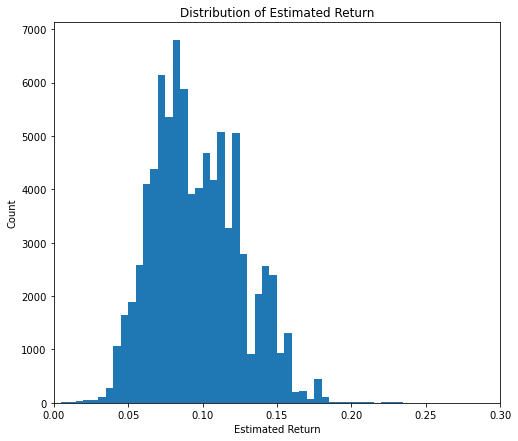

```python
binsize = 0.005
bins = np.arange(0, Prosper_clean.EstimatedReturn.max()+binsize, binsize)

plt.figure(figsize=[8, 7])
plt.hist(data = Prosper_clean, x= 'EstimatedReturn', bins = bins);
print(x_y_t('Estimated Return', 'Count', 'Distribution of Estimated Return'))
plt.xlim(0, 0.30)
```

```python
# We are going to look out for the mean, std etc
Prosper_clean.EstimatedReturn.describe()
```

```
count    84853.000000
mean         0.096068
std          0.030403
min         -0.182700
25%          0.074080
50%          0.091700
75%          0.116600
max          0.283700
Name: EstimatedReturn, dtype: float64
```

The Estimated return is between 0.05 to 0.17. An estimted return from 0.20 to 0.26 is very rare and hard to come by from the distribution

**Monthly Payment**

```
None
```

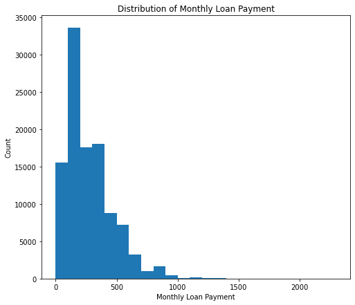

```python
binsize = 100
bins = np.arange(0, Prosper_clean.MonthlyLoanPayment.max()+binsize, binsize)

plt.figure(figsize=[8, 7])
plt.hist(data = Prosper_clean, x= 'MonthlyLoanPayment', bins = bins);
print(x_y_t('Monthly Loan Payment', 'Count', 'Distribution of Monthly Loan Payment'))
```

```python
Prosper_clean.MonthlyLoanPayment.describe()
```

```
count    107554.000000
mean        277.678866
std         192.564168
min           0.000000
25%         136.980000
50%         226.205000
75%         376.700000
max        2251.510000
Name: MonthlyLoanPayment, dtype: float64
```

From the viualization you could tell that the amount of money paid monthly is within the 10's and 100's region. Not so much within the 1000's region. Also looking at the percentiles, much more people pay their monthly loan above a 136.98

**Borrower APR**

```
None
```

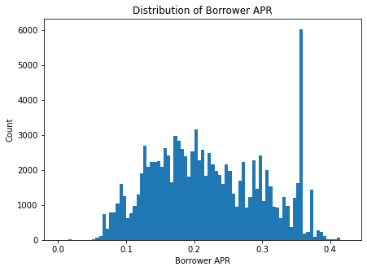

```python
binsize = 0.005
bins = np.arange(0, Prosper_clean.BorrowerAPR.max()+binsize, binsize)

plt.figure(figsize=[7, 5])
plt.hist(data = Prosper_clean, x= 'BorrowerAPR', bins = bins);
print(x_y_t('Borrower APR', 'Count', 'Distribution of Borrower APR'))
```

```python
Prosper_clean.BorrowerAPR.describe()
```

```
count    107554.000000
mean          0.220352
std           0.080820
min           0.006530
25%           0.157130
50%           0.211220
75%           0.285950
max           0.423950
Name: BorrowerAPR, dtype: float64
```

APR is comprised of the interest rate stated on a loan plus fees, origination charges, discount points, and agency fees paid to the lender(Source :https://www.investopedia.com/ask/answers/100314/what-difference-between-interest-rate-and-annual-percentage-rate-apr.asp). Looking at this distribution we can have a look at each borrowers API with the highest been 0.42 .

**LoanOriginalAmount**

```python
Prosper_clean.LoanOriginalAmount.value_counts()
```

```
4000     14101
15000    12270
10000    10852
5000      6401
2000      5773
         ...
10593        1
11446        1
3136         1
4256         1
4292         1
Name: LoanOriginalAmount, Length: 2362, dtype: int64
```

We will be using a log Distribution for thr Loan Original Amount due to the large number counts

```
(500.0, 50000.0)
```

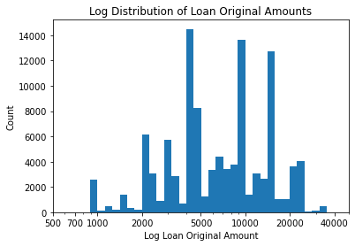

```python
log_binsize = 0.05
bins = 10 ** np.arange(1.5, np.log(Prosper_clean.LoanOriginalAmount.max())+log_binsize, log_binsize)
ticks = [500, 700, 1000, 2000, 5000, 10000, 20000, 40000]

plt.hist(data = Prosper_clean, x= 'LoanOriginalAmount', bins = bins);

plt.xscale('log')
plt.xticks(ticks, ticks)
plt.xlabel('Log Loan Original Amount')
plt.ylabel('Count')
plt.title('Log Distribution of Loan Original Amounts')
plt.xlim(500, 50000)
```

The limits on the x axis was set to have a proper distribution of the curve.

```python
Prosper_clean.LoanOriginalAmount.describe()
```

```
count    107554.000000
mean       8518.340917
std        6272.171802
min        1000.000000
25%        4000.000000
50%        7000.000000
75%       12000.000000
max       35000.000000
Name: LoanOriginalAmount, dtype: float64
```

```python
Prosper_clean.LoanMonthsSinceOrigination.value_counts()
```

```
2     5865
3     5215
5     4899
1     4485
4     4336
      ...
90     304
55     248
92     163
56      20
58      13
Name: LoanMonthsSinceOrigination, Length: 86, dtype: int64
```

**Log Distribution of the loan months since origination**

```
(30.0, 120.0)
```

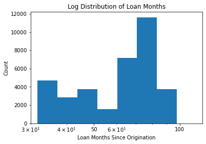

```python
log_binsize = 0.07
bins = 10 ** np.arange(1.5, np.log(Prosper_clean.LoanMonthsSinceOrigination.max())+log_binsize, log_binsize)
ticks = [50, 100, 1000, 2000, 5000, 6000]

plt.hist(data = Prosper_clean, x= 'LoanMonthsSinceOrigination', bins = bins);

plt.xscale('log')
plt.xticks(ticks, ticks)
plt.xlabel('Loan Months Since Origination')
plt.ylabel('Count')
plt.title('Log Distribution of Loan Months')
plt.xlim(30, 120)
```

```python
Prosper_clean.LoanMonthsSinceOrigination.describe()
```

```
count    107554.000000
mean         28.558733
std          27.411125
min           0.000000
25%           6.000000
50%          19.000000
75%          45.000000
max          92.000000
Name: LoanMonthsSinceOrigination, dtype: float64
```

The number of month since the loan originated visual skewed toward the right meaning the data has recorded loans that have been disperesed beyond a month or two

**Define**

Condisdering the data set that have been set to categories under the datatype. We have the:

1. Term : The length of the loan expressed in months
2. LoanStatus: The current status of the loan: Cancelled, Chargedoff, Completed, Current, Defaulted, FinalPaymentInProgress, PastDue.
3. Credit_Score: Consumer credit score rating
4. IncomeRange: The income range of the borrower at the time the listing was created.

**Code**

Plotting the variables with datatype as category

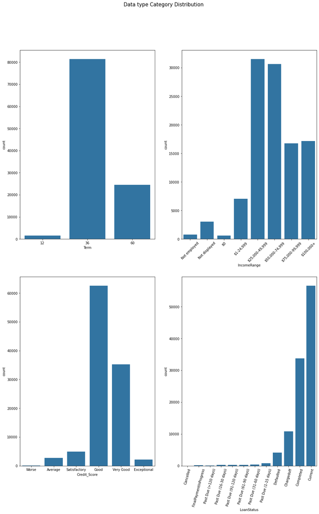

```python
#Setting the labels for the loanstatus and Income range
LoanStatus_labels = ['Cancelled', 'FinalPaymentInProgress', 'Past Due (>120 days)', 'Past Due (16-30 days)', 'Past Due (91-120 days)', 'Past Due (61-90 days)', 'Past Due (31-60 days)', 'Past Due (1-15 days)', 'Defaulted', 'Chargedoff', 'Completed', 'Current']
IncomeRange_labels = ['Not employed', 'Not displayed', '$0', '$1-24,999', '$25,000-49,999', '$50,000-74,999','$75,000-99,999', '$100,000+']

fig, ax = plt.subplots(nrows=2 , ncols = 2, figsize = [16,20])

default_color = sb.color_palette()[0]
sb.countplot(data = Prosper_clean, x = 'Term', color = default_color, ax = ax[0, 0])
sb.countplot(data = Prosper_clean, x = 'IncomeRange', color = default_color, ax = ax[0, 1])
sb.countplot(data = Prosper_clean, x = 'Credit_Score', color = default_color, ax = ax[1, 0])
sb.countplot(data = Prosper_clean, x = 'LoanStatus', color = default_color, ax = ax[1, 1])

ax[0, 1].set_xticklabels(labels = IncomeRange_labels, rotation = 45)
ax[1, 1].set_xticklabels(labels = LoanStatus_labels, rotation = 75)

plt.subplots_adjust(bottom = 0.01)
fig.suptitle("Data type Category Distribution", fontsize=15)

plt.show()
```

From the visualization we can realise that the loan status is skewed towards current. This shows the data had current loan acquisitions more than those that were cancelled or past due.

**Define**

The variable IsBorrowerHomeowner is a boolean value as such we will look at it with a pie chart and donut chart.

**Code**

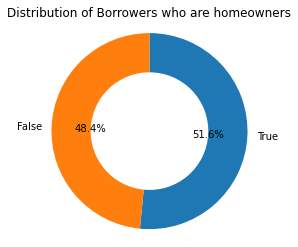

```python
sorted_counts = Prosper_clean['IsBorrowerHomeowner'].value_counts()

plt.pie(sorted_counts, labels = sorted_counts.index, startangle = 90,
        counterclock = False, wedgeprops = {'width' : 0.4}, autopct='%0.01f%%');
plt.axis('square')
plt.title('Distribution of Borrowers who are homeowners')
```

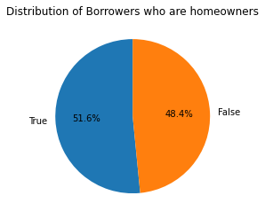

```python
plt.pie(Prosper_clean.IsBorrowerHomeowner.value_counts().values, labels = Prosper_clean.IsBorrowerHomeowner.value_counts().index,
        startangle = 90, autopct='%0.01f%%');

plt.title('Distribution of Borrowers who are homeowners')

plt.show()
```

We can tell from the charts that approximately 51% borrowers are homeowners and 48% are not homeowners

**Define**

Drawing the charts for employment status

**Code**

```
(array([0, 1, 2, 3, 4, 5, 6, 7]),
 [Text(0, 0, 'Self-employed'),
```

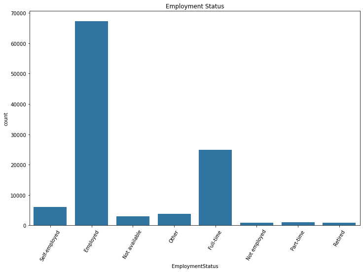

```python
plt.figure(figsize = [12, 8])
default_color = sb.color_palette()[0]
sb.countplot(data = Prosper_clean, x = 'EmploymentStatus', color = default_color)
plt.title('Employment Status')
plt.xticks(rotation = 60)
```

From the chart, more borrowers are employed and more are in full time

### Discuss the distribution(s) of your variable(s) of interest. Were there any unusual points? Did you need to perform any transformations?

> The LoanMonthsSinceOrigination variable took on a large range of values, so I opted for a log transform. The number of month since the loan originated visual skewed toward the right meaning the data has recorded loans that have been disperesed beyond a month or two

> Most people who went in for a loan are employed. The retired, part-time and unemployed workers were the least people who went in for a loan

### Of the features you investigated, were there any unusual distributions? Did you perform any operations on the data to tidy, adjust, or change the form of the data? If so, why did you do this?

> I converted the scor names, score ranges into a credit_score column to correspond to the CreditScoreRangeLower variables. Also the ListingCategory (numeric) variables had to be changed into a categorical type for it to be useful in the data assessment.

## Bivariate Exploration

To start off with, I will want to look at the pairwise correlations present between features in the data i.e (numeric and categories)

```python
numeric_vars = ['EstimatedReturn', 'BorrowerAPR', 'LoanMonthsSinceOrigination', 'LoanOriginalAmount', 'MonthlyLoanPayment']
categoric_vars = ['IncomeRange', 'Credit_Score', 'EmploymentStatus']
```

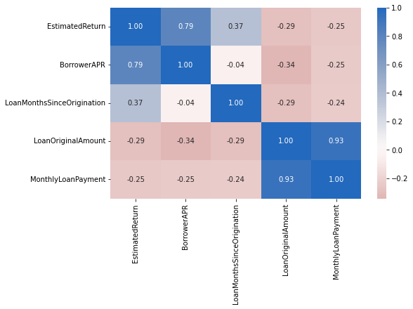

```python
# correlation plot
plt.figure(figsize = [8, 5])
sb.heatmap(Prosper_clean[numeric_vars].corr(), annot = True, fmt = '.2f',
           cmap = 'vlag_r', center = 0)
plt.show()
```

```
Prosper_clean.shape= (107554, 18)
Prosper_clean_samp.shape= (500, 18)
```

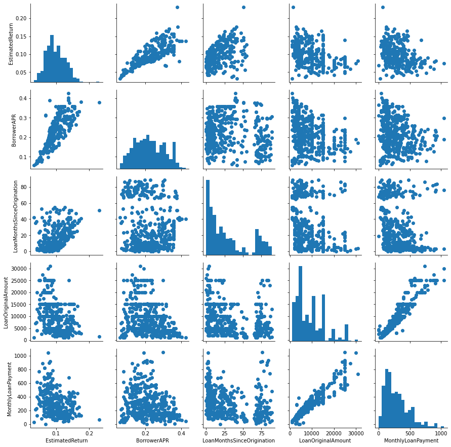

```python
# plot matrix: sample 500 Prosper_clean so that plots are clearer and they render faster
print("Prosper_clean.shape=",Prosper_clean.shape)
Prosper_clean_samp = Prosper_clean.sample(n=500, replace = False)
print("Prosper_clean_samp.shape=",Prosper_clean_samp.shape)

g = sb.PairGrid(data = Prosper_clean_samp, vars = numeric_vars)
g = g.map_diag(plt.hist, bins = 20);
g.map_offdiag(plt.scatter)
```

**Monthly Loan Payment and LoanOriginalAmount against the Credit_Score, Income Range and Employment Status**

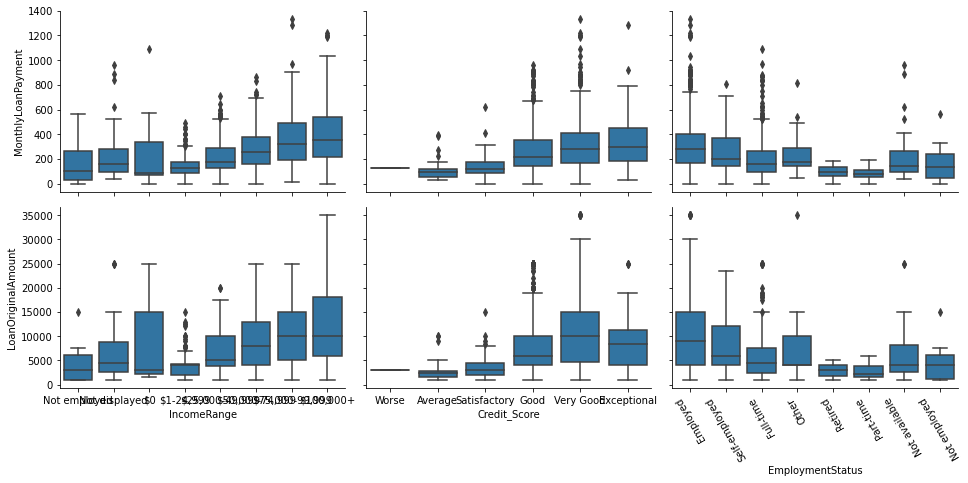

```python
# Box plot matrix of numeric features against categorical features.

Prosper_clean_samp = Prosper_clean.sample(n=2000, replace = False)


def boxgrid(x, y, **kwargs):
    """ Quick hack for creating box plots with seaborn's PairGrid. """
    default_color = sb.color_palette()[0]
    sb.boxplot(x=x, y=y, color=default_color)

plt.figure(figsize = [15, 15])
g = sb.PairGrid(data = Prosper_clean_samp, y_vars = ['MonthlyLoanPayment', 'LoanOriginalAmount'], x_vars = categoric_vars,
                height = 3, aspect = 1.5)
g.map(boxgrid)
plt.xticks(rotation = 120)
plt.show();
```

### Talk about some of the relationships you observed in this part of the investigation. How did the feature(s) of interest vary with other features in the dataset?

> The Loan original amount are highly correlated with the monthly loan payment. Also the correlation between the Estimated return and Borrower APR is very high. This shows the estimated return is affected by the Borrowers APR.

> The loan original amount increases per your employment status. Borrowers who are employed are able to obtain high loan amounts, than the unemployed and part time workers. Also, those with excellent and good credit scoreshad great loan amounts. Theose with high income ranges also obtain good loan amounts.

### Did you observe any interesting relationships between the other features (not the main feature(s) of interest)?

> Monthly loan payments across the categories also show how much each category is contributing. Under employment status we can tell that those employed are able to pay their monthly loan payments than those who aren't employed or part time. Also those with good credit scores are able to make thier monthly payments compared to those with poor ones

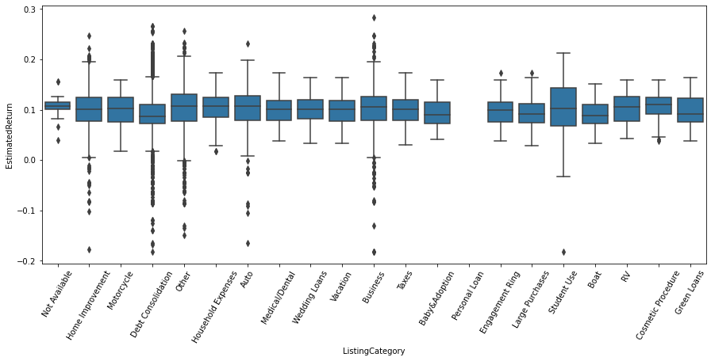

```python
plt.figure(figsize = [15, 6])

sb.boxplot(data = Prosper_clean, x = 'ListingCategory', y = 'EstimatedReturn', color = default_color);
plt.xticks(rotation = 60);
```

The Estimated returns of investors on the various loans listed categories. Every investor will consider their returns on the usage of the loan by loan borrowers.

```python
Prosper_clean.info()
```

```
<class 'pandas.core.frame.DataFrame'>
Int64Index: 107554 entries, 0 to 113936
Data columns (total 18 columns):
 #   Column                      Non-Null Count   Dtype
---  ------                      --------------   -----
 0   ListingKey                  107554 non-null  object
 1   ListingCreationDate         107554 non-null  object
 2   Term                        107554 non-null  category
 3   LoanStatus                  107554 non-null  category
 4   BorrowerAPR                 107554 non-null  float64
 5   LenderYield                 107554 non-null  float64
 6   EstimatedReturn             84853 non-null   float64
 7   ListingCategory             107554 non-null  object
 8   BorrowerState               107554 non-null  object
 9   EmploymentStatus            107554 non-null  object
 10  IsBorrowerHomeowner         107554 non-null  bool
 11  CreditScoreRangeLower       107554 non-null  float64
 12  Credit_Score                107554 non-null  category
 13  IncomeRange                 107554 non-null  category
 14  MonthlyLoanPayment          107554 non-null  float64
 15  LoanMonthsSinceOrigination  107554 non-null  int64
 16  LoanOriginalAmount          107554 non-null  int64
 17  Recommendations             107554 non-null  int64
dtypes: bool(1), category(4), float64(5), int64(3), object(5)
memory usage: 12.0+ MB
```

```python
Prosper_clean.BorrowerState.value_counts()
```

```
CA    14577
TX     6699
NY     6692
FL     6674
IL     5898
GA     4904
OH     4196
MI     3543
VA     3272
NJ     3093
NC     3055
WA     3008
PA     2968
MD     2812
MO     2583
MN     2316
MA     2224
CO     2188
IN     2067
AZ     1878
WI     1837
OR     1787
TN     1734
AL     1667
CT     1625
SC     1118
NV     1090
KS     1050
KY      983
OK      966
LA      950
UT      870
AR      853
MS      785
NE      671
ID      595
NH      547
NM      466
RI      435
HI      408
WV      385
DC      382
MT      325
DE      300
VT      207
AK      200
SD      189
IA      186
WY      150
ME       97
ND       49
Name: BorrowerState, dtype: int64
```

```
(array([ 0,  1,  2,  3,  4,  5,  6,  7,  8,  9, 10, 11, 12, 13, 14, 15, 16,
        17, 18, 19, 20, 21, 22, 23, 24, 25, 26, 27, 28, 29, 30, 31, 32, 33,
        34, 35, 36, 37, 38, 39, 40, 41, 42, 43, 44, 45, 46, 47, 48, 49, 50]),
 [Text(0, 0, 'CO'),
```

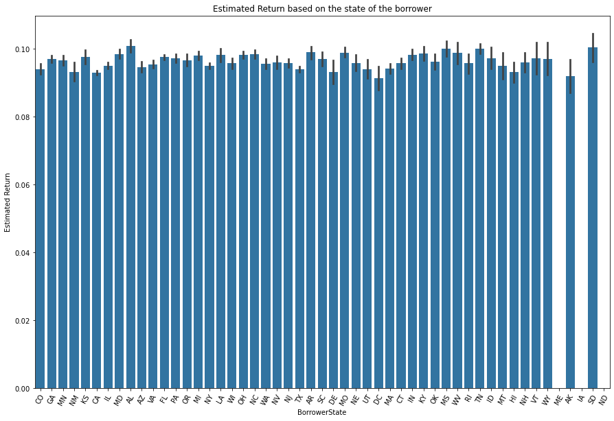

```python
base_color = sb.color_palette()[0]
plt.figure(figsize = [15, 10])
sb.barplot(data = Prosper_clean, x = 'BorrowerState', y = 'EstimatedReturn', color = base_color)
plt.title('Estimated Return based on the state of the borrower')
plt.xlabel('BorrowerState')
plt.ylabel('Estimated Return')
plt.xticks(rotation = 60)
```

**Drawing a chart of Borrower APR and Estimated return against the Term and also the Credit_Score**

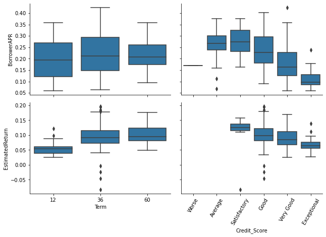

```python
# Box plot matrix of numeric features against categorical features.

Prosper_clean_samp = Prosper_clean.sample(n=2000, replace = False)


def boxgrid(x, y, **kwargs):
    """ Quick hack for creating box plots with seaborn's PairGrid. """
    default_color = sb.color_palette()[0]
    sb.boxplot(x=x, y=y, color=default_color)

plt.figure(figsize = [15, 15])
g = sb.PairGrid(data = Prosper_clean_samp, y_vars = ['BorrowerAPR', 'EstimatedReturn'], x_vars = ['Term', 'Credit_Score'],
                height = 3, aspect = 1.5)
g.map(boxgrid)
plt.xticks(rotation = 60)
plt.show();
```

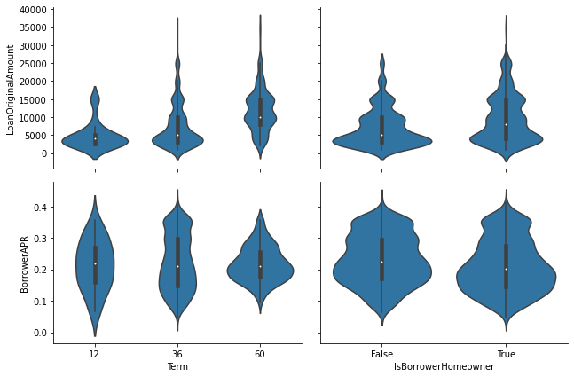

```python
Prosper_clean_samp = Prosper_clean.sample(n=2000, replace = False)


def boxgrid(x, y, **kwargs):
    """ Quick hack for creating box plots with seaborn's PairGrid. """
    default_color = sb.color_palette()[0]
    sb.violinplot(x=x, y=y, color=default_color)

plt.figure(figsize = [10, 10])
g = sb.PairGrid(data = Prosper_clean_samp, y_vars = ['LoanOriginalAmount', 'BorrowerAPR'], x_vars = ['Term', 'IsBorrowerHomeowner'],
                height = 3, aspect = 1.5)
g.map(boxgrid)
plt.show();
```

### Did you observe any interesting relationships between the other features (not the main feature(s) of interest)?

> The borrower state didn't have any major influence on the estimated return by investors. Meaning estimated return is not influenced by the state in which one lives

## Multivariate Exploration

> Create plots of three or more variables to investigate your data even further. Make sure that your investigations are justified, and follow from your work in the previous sections.

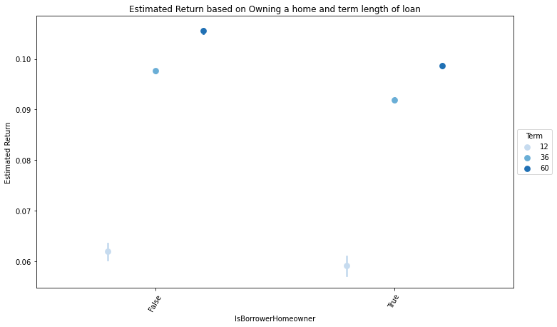

```python
fig = plt.figure(figsize = [12,7])
ax = sb.pointplot(data = Prosper_clean, x = 'IsBorrowerHomeowner', y = 'EstimatedReturn',  hue = 'Term',
           palette = 'Blues', linestyles = '', dodge = 0.4)

plt.title('Estimated Return based on Owning a home and term length of loan')
plt.xlabel('IsBorrowerHomeowner')
plt.ylabel('Estimated Return')
plt.xticks(rotation = 60)
# plot legend outside of figure
ax.legend(loc='center left', title='Term', bbox_to_anchor=(1, 0.5))
plt.show();
```

Under the Estimated return based on whether a borrower is a home owner and considering the length of the loan.

The Estimated return seems to for home owners under the various term length seems less than those without homes. But as said the difference is minimal

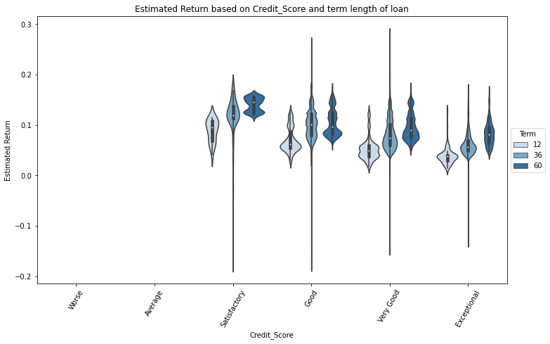

```python
fig = plt.figure(figsize = [12,7])
ax = sb.violinplot(data = Prosper_clean, x = 'Credit_Score', y = 'EstimatedReturn',  hue = 'Term',
           palette = 'Blues', linestyles = '', dodge = 0.4)

plt.title('Estimated Return based on Credit_Score and term length of loan')
plt.xlabel('Credit_Score')
plt.ylabel('Estimated Return')
plt.xticks(rotation = 60)
# plot legend outside of figure
ax.legend(loc='center left', title='Term', bbox_to_anchor=(1, 0.5))
plt.show();
```

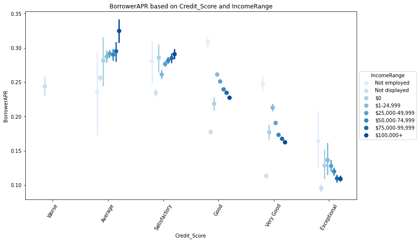

```python
fig = plt.figure(figsize = [12,7])
ax = sb.pointplot(data = Prosper_clean, x = 'Credit_Score', y = 'BorrowerAPR',  hue = 'IncomeRange',
           palette = 'Blues', linestyles = '', dodge = 0.4)

plt.title('BorrowerAPR based on Credit_Score and IncomeRange')
plt.xlabel('Credit_Score')
plt.ylabel('BorrowerAPR')
plt.xticks(rotation = 60)
# plot legend outside of figure
ax.legend(loc='center left', title='IncomeRange', bbox_to_anchor=(1, 0.5))
plt.show();
```

With an exceptional credit score, even if you are not employed your Borrower APR will be lower than someone with an average or satisfactory credit_score and earning $100,000+. This clearly shows one's credit score is important and directly affects the Borrowers APR

### Talk about some of the relationships you observed in this part of the investigation. Were there features that strengthened each other in terms of looking at your feature(s) of interest?

> The estimated return wasn't much affected if one was a homeowner or not. It was marginally high for those who had no ownership of homes than those who had ownership of homes.

> The term length and credit score also influenced one's estimated return.

> Been unemployed affect one's APR no matter the credit score one had

### Were there any interesting or surprising interactions between features?

> The term length and the credit score had a linear relation. The borrower APR decreased with a good credit score.

## Conclusions

It was insightful and educative as well. Some key points taking are:

```python
from subprocess import call
call(['python', '-m', 'nbconvert', 'Part_I_exploration_template.ipynb'])
```

```
1
```